# Prediction Assignment

Chua Wee Young

Friday, August 21, 2015

# Background

Using devices such as Jawbone Up, Nike FuelBand, and Fitbit it is now possible to collect a large amount of data about personal activity relatively inexpensively. These type of devices are part of the quantified self movement - a group of enthusiasts who take measurements about themselves regularly to improve their health, to find patterns in their behavior, or because they are tech geeks. One thing that people regularly do is quantify how much of a particular activity they do, but they rarely quantify how well they do it. In this project, your goal will be to use data from accelerometers on the belt, forearm, arm, and dumbell of 6 participants. They were asked to perform barbell lifts correctly and incorrectly in 5 different ways. More information is available from the website here: http://groupware.les.inf.puc-rio.br/har (see the section on the Weight Lifting Exercise Dataset).

# datasets

```r
require(data.table)
```

```r
training_url <- "http://d396qusza40orc.cloudfront.net/predmachlearn/pml-training.csv"
training_data <- read.csv(url(training_url), na.strings=c("", "NA"))

testing_url <- "http://d396qusza40orc.cloudfront.net/predmachlearn/pml-testing.csv"
testing_data <- read.csv(url(testing_url), na.strings=c("", "NA"))
```

# cleansing

```r
NAs <- apply(training_data,2,function(x) {sum(is.na(x))})
training_data <- training_data[,which(NAs == 0)]
training_data   <- training_data[,-c(1:7)]
testing_data <- testing_data[,-c(1:7)]
```

Split the dataset into a 60% training and 40% probing dataset.

```r
library(lattice)
library(ggplot2)
library(caret)
set.seed(13)
trainIndex <- createDataPartition(y = training_data$classe, p=0.6,list=FALSE);
train_data <- training_data[trainIndex,];
test_data <- training_data[-trainIndex, ]
```

Retrieve the dimensions / head

```r
dim(train_data)
```

```
## [1] 11776    53
```

```r
dim(test_data)
```

```
## [1] 7846   53
```

```r
#head(train_data)
#head(test_data)
```

# Recursive Partitioning and Regression Trees

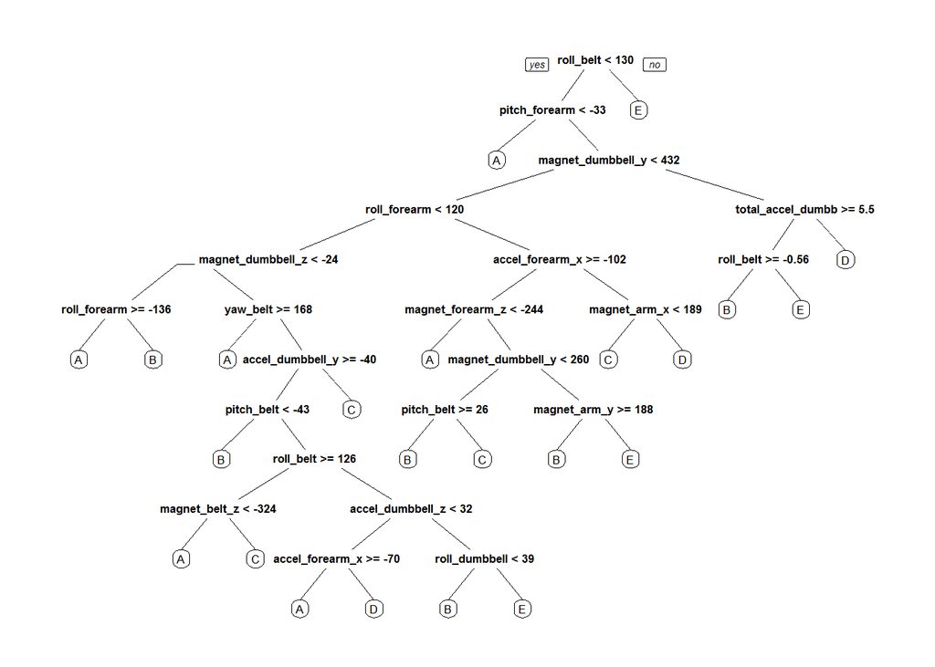

```r
library(rpart)
library(rpart.plot)
train_model <- rpart(classe ~ ., data=train_data, method="class")

rpart.plot(train_model)
```

```r
train_prediction <- predict(train_model, test_data, type = "class")

library(e1071)
# Test results on our subTesting data set:
confusionMatrix(test_data$classe, train_prediction)
```

```
## Confusion Matrix and Statistics
##
##           Reference
## Prediction    A    B    C    D    E
##          A 2038   82   44   51   17
##          B  270  958  126  113   51
##          C   88  150  957  119   54
##          D  133  131  134  763  125
##          E   29  142   99  100 1072
##
## Overall Statistics
##
##                Accuracy : 0.7377
##                  95% CI : (0.7278, 0.7474)
##     No Information Rate : 0.326
##     P-Value [Acc > NIR] : < 2.2e-16
##
##                   Kappa : 0.6663
##  Mcnemar's Test P-Value : < 2.2e-16
##
## Statistics by Class:
##
##                      Class: A Class: B Class: C Class: D Class: E
## Sensitivity            0.7967   0.6548   0.7037  0.66579   0.8127
## Specificity            0.9633   0.9123   0.9366  0.92194   0.9433
## Pos Pred Value         0.9131   0.6311   0.6996  0.59331   0.7434
## Neg Pred Value         0.9074   0.9202   0.9378  0.94162   0.9614
## Prevalence             0.3260   0.1865   0.1733  0.14606   0.1681
## Detection Rate         0.2598   0.1221   0.1220  0.09725   0.1366
## Detection Prevalence   0.2845   0.1935   0.1744  0.16391   0.1838
## Balanced Accuracy      0.8800   0.7835   0.8202  0.79387   0.8780
```

Accuracy is only at 0.7377 and the error rate would be 0.2623

# Random Forest

```r
library(randomForest)
train_random_forest <- randomForest(classe ~. , data=train_data)

train_random_forest_prediction <- predict(train_random_forest, test_data, type = "class")

# Test results on our subTesting data set:
confusionMatrix(test_data$classe, train_random_forest_prediction)
```

```
## Confusion Matrix and Statistics
##
##           Reference
## Prediction    A    B    C    D    E
##          A 2231    1    0    0    0
##          B    2 1515    1    0    0
##          C    0    9 1359    0    0
##          D    0    0   24 1260    2
##          E    0    0    1    2 1439
##
## Overall Statistics
##
##                Accuracy : 0.9946
##                  95% CI : (0.9928, 0.9961)
##     No Information Rate : 0.2846
##     P-Value [Acc > NIR] : < 2.2e-16
##
##                   Kappa : 0.9932
##  Mcnemar's Test P-Value : NA
##
## Statistics by Class:
##
##                      Class: A Class: B Class: C Class: D Class: E
## Sensitivity            0.9991   0.9934   0.9812   0.9984   0.9986
## Specificity            0.9998   0.9995   0.9986   0.9961   0.9995
## Pos Pred Value         0.9996   0.9980   0.9934   0.9798   0.9979
## Neg Pred Value         0.9996   0.9984   0.9960   0.9997   0.9997
## Prevalence             0.2846   0.1944   0.1765   0.1608   0.1837
## Detection Rate         0.2843   0.1931   0.1732   0.1606   0.1834
## Detection Prevalence   0.2845   0.1935   0.1744   0.1639   0.1838
## Balanced Accuracy      0.9995   0.9965   0.9899   0.9972   0.9991
```

Accuracy is at 0.9946, much better than the recursive partitioning. Error rate would be 0.0054

```r
train_random_forest_test <- randomForest(classe ~. , data=test_data)

train_random_forest_test_prediction <- predict(train_random_forest_test, test_data, type = "class")

# Test results on our subTesting data set:
confusionMatrix(test_data$classe, train_random_forest_test_prediction)
```

```
## Confusion Matrix and Statistics
##
##           Reference
## Prediction    A    B    C    D    E
##          A 2232    0    0    0    0
##          B    0 1518    0    0    0
##          C    0    0 1368    0    0
##          D    0    0    0 1286    0
##          E    0    0    0    0 1442
##
## Overall Statistics
##
##                Accuracy : 1
##                  95% CI : (0.9995, 1)
##     No Information Rate : 0.2845
##     P-Value [Acc > NIR] : < 2.2e-16
##
##                   Kappa : 1
##  Mcnemar's Test P-Value : NA
##
## Statistics by Class:
##
##                      Class: A Class: B Class: C Class: D Class: E
## Sensitivity            1.0000   1.0000   1.0000   1.0000   1.0000
## Specificity            1.0000   1.0000   1.0000   1.0000   1.0000
## Pos Pred Value         1.0000   1.0000   1.0000   1.0000   1.0000
## Neg Pred Value         1.0000   1.0000   1.0000   1.0000   1.0000
## Prevalence             0.2845   0.1935   0.1744   0.1639   0.1838
## Detection Rate         0.2845   0.1935   0.1744   0.1639   0.1838
## Detection Prevalence   0.2845   0.1935   0.1744   0.1639   0.1838
## Balanced Accuracy      1.0000   1.0000   1.0000   1.0000   1.0000
```

# Submission

```r
library(MASS)

assignment_prediction <- predict(train_random_forest, testing_data, type = "class")

pml_write_files  = function(x){
  n = length(x)
  for(i in 1:n){
    filename = paste0("problem_id_",i,".txt")
    write.table(x[i],file=filename,quote=FALSE,row.names=FALSE,col.names=FALSE)
  }
}

pml_write_files (assignment_prediction)
```